# Introdução a Linguagem R

Robson Dias, CIN-UFPE

Agosto, 2017

# Sumário

1. Introdução
2. R Core
3. Exemplo Prático
4. Funções em R
5. Gráficos
6. ML
7. OO em R
8. Packages Utéis

# Introdução R

## História R

[figure not shown]

## R no Mundo

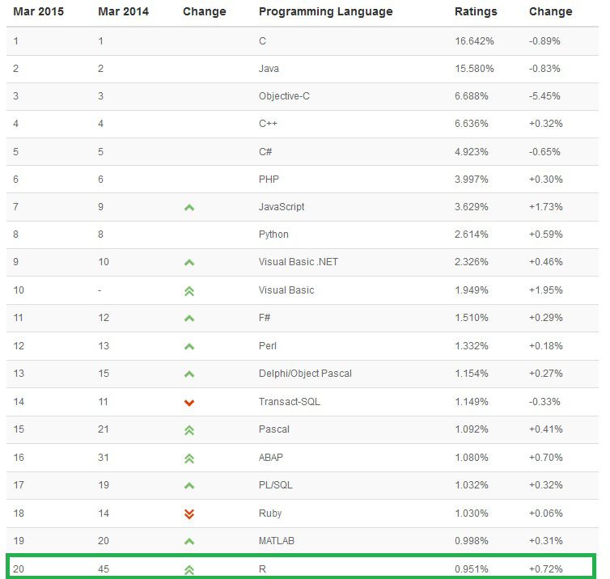

## Crescimento de Usuários

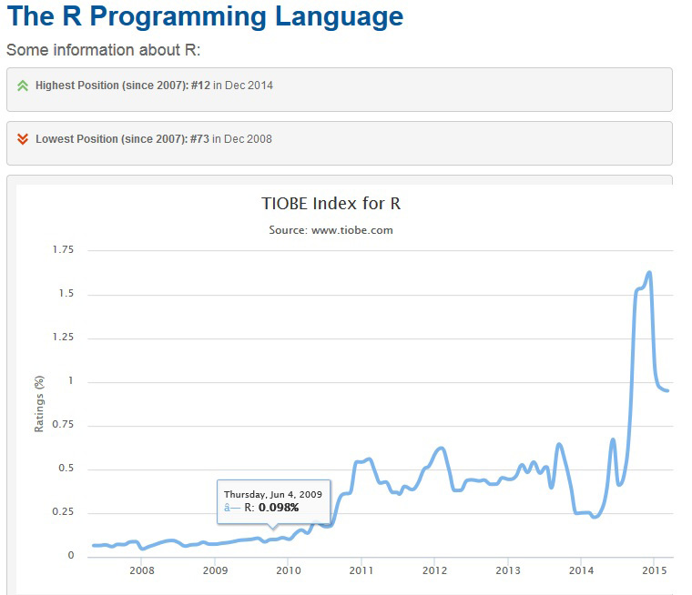

## Por que R?

1. Vantagens
- Free
- Packages
- Comunidade
- Edge Tools
- Integração Fortran,C e C++
- Analise de Dados
2. Desvantagens
- Lenta
- Qualidade do Pacotes
- Incosistência entre pacotes

# Ferramentas

## Interpretador R

[figure not shown]

[Linguagem R](http://www.r-project.org/)

### IDE RStudio

[figure not shown]

[RStudio] (http://www.rstudio.com)

### IDE RStudio

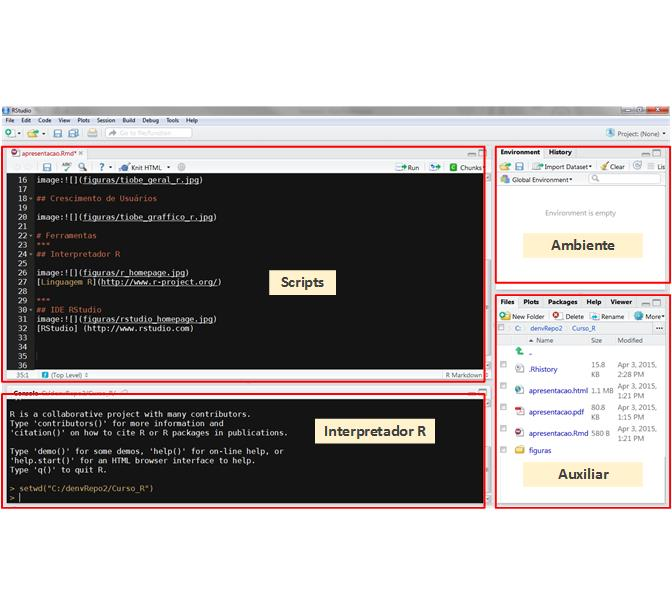

[RStudio] (http://www.rstudio.com)

# R Core

## Ajuda

| Comando | Função |
| --- | --- |
| apropos(“mean”) | Lista objetos com mean |
| help(“mean”) | Encontra ajuda da função mean(?mean) |
| help.search(“mean”) | Procua nas ajudas (??mean) |
| example(“mean”) | Encontra Exemplo |
| help(package=“ggplot2”) | Lista Informações sobre o package |
| vignette | Lista vignette |

### apropos

```r
> apropos("mean")
```

```
##  [1] ".colMeans"     ".rowMeans"     "colMeans"      "kmeans"
##  [5] "mean"          "mean.Date"     "mean.default"  "mean.difftime"
##  [9] "mean.POSIXct"  "mean.POSIXlt"  "rowMeans"      "weighted.mean"
```

### Help

```r
> help("mean")
```

```
## starting httpd help server ... done
```

```r
> ?mean
```

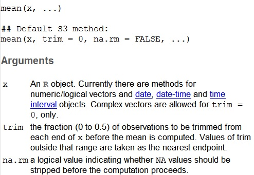

### Exemplo

```r
> example("mean")
```

```
##
## mean> x <- c(0:10, 50)
##
## mean> xm <- mean(x)
##
## mean> c(xm, mean(x, trim = 0.10))
## [1] 8.75 5.50
```

### Help

```r
> help.search("mean")
```

[figure not shown]

### Help por package

[figure not shown]

```r
> help(package="ggplot2")
```

### Vignettes

```r
> vignette()
> vignette("amelia")
```

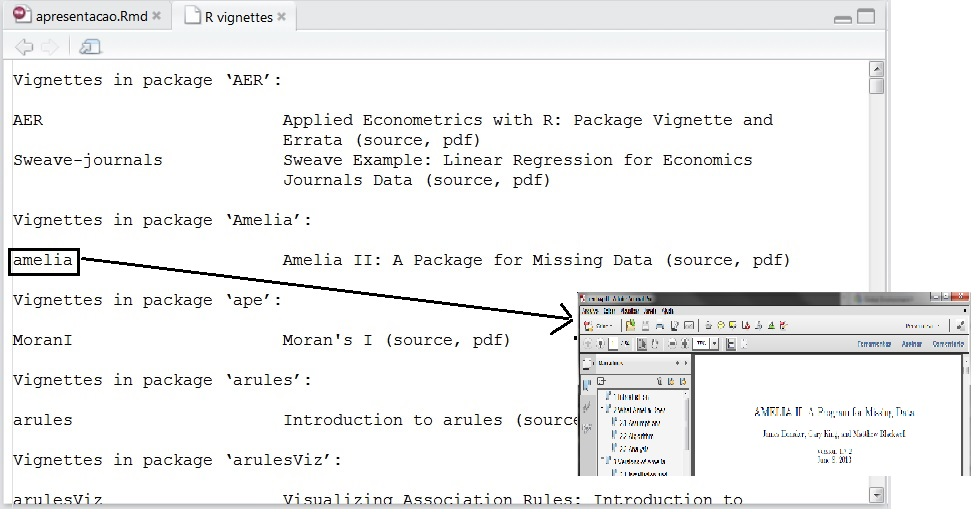

## Packages R

Listar Packages

```r
installed.packages()
```

Instalação de Packages

```r
install.packages("ggplot2")
```

Carregando Packages

```r
library("ggplot2")
```

Verificando Instalação

```r
if (!require(ggplot2)){
  install.packages("ggplot2")
}
```

# R Core

## Tipo de Dados

Tipos

```r
#Tipos de Dados
#----------------
a<-1 # double
b<-1L #integer
c<-"A" #character
d<-TRUE #logical
e<-1+1i #complex
f<-raw(8) #raw
```

```r
#Verificando o tipo
#----------------
is.double(a);is.numeric(a);is.integer(b);is.numeric(b)
## [1] TRUE
## [1] TRUE
## [1] TRUE
## [1] TRUE
is.character(c);is.logical(d);is.complex(e);is.raw(f);
## [1] TRUE
## [1] TRUE
## [1] TRUE
## [1] TRUE
```

Coerção

```r
#----------------
a <- "1"
a <- as.numeric(a)
a
## [1] 1
```

```r
#----------------
b <- c("1","2","3")
b <- as.numeric(b)
b
## [1] 1 2 3
```

## Estrutura de Dados em R

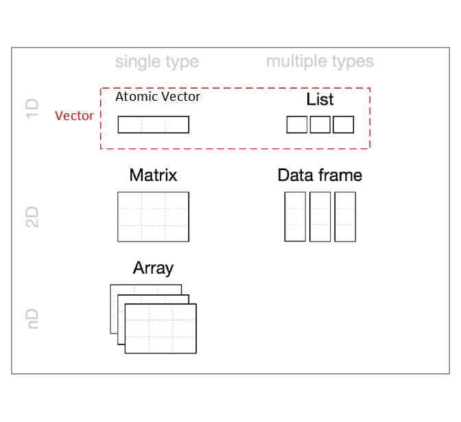

Atomic Vectors

```r
atom_vec<-c(1,2,3,4,5,6)
is.atomic(atom_vec)
## [1] TRUE
is.vector(atom_vec)
## [1] TRUE
```

Factors

```r
sexo <- factor(c("M", "F", "F", "M"))
str(sexo)
##  Factor w/ 2 levels "F","M": 2 1 1 2
is.vector(sexo)
## [1] FALSE
is.atomic(sexo)
## [1] TRUE
class(sexo)
## [1] "factor"
typeof(sexo)
## [1] "integer"
```

Factors

```r
attributes(sexo)
## $levels
## [1] "F" "M"
##
## $class
## [1] "factor"
```

Operações Atomic Vectors

```r
atom_vec[1:3]
## [1] 1 2 3
atom_vec[1]
## [1] 1
atom_vec[-1]
## [1] 2 3 4 5 6
atom_vec*2
## [1]  2  4  6  8 10 12
max(atom_vec)
## [1] 6
which.max(atom_vec)
## [1] 6
which.min(atom_vec)
## [1] 1
sqrt(atom_vec)
## [1] 1.000000 1.414214 1.732051 2.000000 2.236068 2.449490
str(atom_vec)
##  num [1:6] 1 2 3 4 5 6
```

List

```r
pessoa<-list()
pessoa$nome<-"robson"
pessoa$login<-"rdat"
pessoa$bonito<-TRUE
is.list(pessoa)
## [1] TRUE
is.vector(pessoa)
## [1] TRUE
is.atomic(pessoa)
## [1] FALSE
```

Operações List

```r
cat("nome:",pessoa$nome)
## nome: robson
cat("login:",pessoa[['login']])
## login: rdat
length(pessoa)
## [1] 3
str(pessoa)
## List of 3
##  $ nome  : chr "robson"
##  $ login : chr "rdat"
##  $ bonito: logi TRUE
```

Matrix

```r
m<-matrix(c(1,2,3,4,5,6,7,8,9),3,3,TRUE)
is.matrix(m)
## [1] TRUE
dim(m)
## [1] 3 3
nrow(m)
## [1] 3
str(m)
##  num [1:3, 1:3] 1 4 7 2 5 8 3 6 9
```

Operações Matrix

```r
m
##      [,1] [,2] [,3]
## [1,]    1    2    3
## [2,]    4    5    6
## [3,]    7    8    9
m[1,1]
## [1] 1
m[1,]
## [1] 1 2 3
m[,1]
## [1] 1 4 7
m[1:2,1:2]
##      [,1] [,2]
## [1,]    1    2
## [2,]    4    5
```

Como podemos fazer um matriz com a 1º e 3º Linhas ?

Data Frames

```r
nomes<-c("Brasil","Argentina","Alemanha")
primeiroMundo<-c(FALSE,FALSE,TRUE)
NrTitulos<-c(5,2,4)
df<-data.frame(nomes,NrTitulos,primeiroMundo)
str(df)
## 'data.frame':    3 obs. of  3 variables:
##  $ nomes        : Factor w/ 3 levels "Alemanha","Argentina",..: 3 2 1
##  $ NrTitulos    : num  5 2 4
##  $ primeiroMundo: logi  FALSE FALSE TRUE
```

```r
str(df)
```

```
## 'data.frame':    3 obs. of  3 variables:
##  $ nomes        : Factor w/ 3 levels "Alemanha","Argentina",..: 3 2 1
##  $ NrTitulos    : num  5 2 4
##  $ primeiroMundo: logi  FALSE FALSE TRUE
```

```r
summary(df)
```

```
##        nomes     NrTitulos     primeiroMundo
##  Alemanha :1   Min.   :2.000   Mode :logical
##  Argentina:1   1st Qu.:3.000   FALSE:2
##  Brasil   :1   Median :4.000   TRUE :1
##                Mean   :3.667   NA's :0
##                3rd Qu.:4.500
##                Max.   :5.000
```

Data Frames

```r
class(df)
## [1] "data.frame"
typeof(df)
## [1] "list"
nrow(df)
## [1] 3
ncol(df)
## [1] 3
```

Operações Data Frame

```r
df[1,]
##    nomes NrTitulos primeiroMundo
## 1 Brasil         5         FALSE
df[,1]
## [1] Brasil    Argentina Alemanha
## Levels: Alemanha Argentina Brasil
df$nomes
## [1] Brasil    Argentina Alemanha
## Levels: Alemanha Argentina Brasil
df$nomes[1]
## [1] Brasil
## Levels: Alemanha Argentina Brasil
summary(df)
##        nomes     NrTitulos     primeiroMundo
##  Alemanha :1   Min.   :2.000   Mode :logical
##  Argentina:1   1st Qu.:3.000   FALSE:2
##  Brasil   :1   Median :4.000   TRUE :1
##                Mean   :3.667   NA's :0
##                3rd Qu.:4.500
##                Max.   :5.000
```

Operações Data Frame Dataset mtcars

```r
colnames(mtcars)
##  [1] "mpg"  "cyl"  "disp" "hp"   "drat" "wt"   "qsec" "vs"   "am"   "gear"
## [11] "carb"
?mtcars
```

```r
head(mtcars,3)
##                mpg cyl disp  hp drat    wt  qsec vs am gear carb
## Mazda RX4     21.0   6  160 110 3.90 2.620 16.46  0  1    4    4
## Mazda RX4 Wag 21.0   6  160 110 3.90 2.875 17.02  0  1    4    4
## Datsun 710    22.8   4  108  93 3.85 2.320 18.61  1  1    4    1
```

```r
tail(mtcars,3)
##                mpg cyl disp  hp drat   wt qsec vs am gear carb
## Ferrari Dino  19.7   6  145 175 3.62 2.77 15.5  0  1    5    6
## Maserati Bora 15.0   8  301 335 3.54 3.57 14.6  0  1    5    8
## Volvo 142E    21.4   4  121 109 4.11 2.78 18.6  1  1    4    2
```

## Exemplo Prático

[figure not shown]

Arquivos csv

[figure not shown]

Passo 1: Ler o arquivo carCoords1.csv

```r
carCoords1<-read.csv(file="carCoords1.csv",sep=",")
```

Passo 2: Ler o arquivo carCoords2.csv

```r
carCoords2<-read.csv(file="carCoords2.csv",sep=";")
```

Passo 3 : Juntar os dados dos Arquivos CSVs

```r
carCoords<-rbind(carCoords1,carCoords2)
carCoords<-carCoords[,c("lat","lon","pError")]
```

Passo 4 : Juntar o novo Data Frame com o DataSet mtcars

```r
mtcars2<-cbind(mtcars,carCoords)
```

Salvando Nosso Trabalho

```r
#Salvando
save(mtcars2,file="mtcars2.RData")
#Recuperando
load(file="mtcars2.RData")
```

Outra Opção

```r
#Escrever em um arquivo csv
write.csv(mtcars2,file="mtcars2.csv",row.names=FALSE)
```

# Funções em R

```r
pot<-function(x,n=2){
  x^n
}
formals(pot)
## $x
##
##
## $n
## [1] 2
body(pot)
## {
##     x^n
## }
environment(pot)
## <environment: R_GlobalEnv>
```

Escopo

```r
y<-10
f1 <- function(z){
  z+y
}
f1(5)
```

```r
y<-10
f1 <- function(z,y){
  z+y
}
f1(5)
```

Estilo

```r
normalizar <- function(x, intervalo){
  #Normaliza uma matriz X
  #Args:
    # x:Matriz a normalizar
    # intervalo: intervalo a normalizar vetor cumprimento dois
  #Retorno:
    #resp(tipo list)
    #respN$X_n matriz x normalizada no intervalo dado
    #respN$ScalaM matrix com a e b (ax+b)
  #Coloque o ´codigo aqui...

}
```

Apresentando o NA

```r
notas<-c(8.5,7,8,10,NA)
mean(notas)
max(notas)
#Qual a saída?
```

```r
notas<-c(8.5,7,8,10,NA)
mean(notas,na.rm = TRUE)
## [1] 8.375
max(notas,na.rm = TRUE)
## [1] 10
```

## Estrutura de código

se senão…

```r
a<-NULL
if (a==NULL){
  cat("a é null")
} else {
  cat("a não é null")
}
#Qual a saída?
```

usando is.null

```r
a<-NULL
if (is.null(a)){
  cat("a é null")
} else {
  cat("a não é null")
}
## a é null
#Qual a saída?
```

## Loops

For com seq (dataFrames)

```r
for (i in seq(1,nrow(mtcars))){
  cat("Carro ",i,": ",rownames(mtcars)[i],"\n",sep="")
}
## Carro 1: Mazda RX4
## Carro 2: Mazda RX4 Wag
## Carro 3: Datsun 710
## Carro 4: Hornet 4 Drive
## Carro 5: Hornet Sportabout
## Carro 6: Valiant
## Carro 7: Duster 360
## Carro 8: Merc 240D
## Carro 9: Merc 230
## Carro 10: Merc 280
## Carro 11: Merc 280C
## Carro 12: Merc 450SE
## Carro 13: Merc 450SL
## Carro 14: Merc 450SLC
## Carro 15: Cadillac Fleetwood
## Carro 16: Lincoln Continental
## Carro 17: Chrysler Imperial
## Carro 18: Fiat 128
## Carro 19: Honda Civic
## Carro 20: Toyota Corolla
## Carro 21: Toyota Corona
## Carro 22: Dodge Challenger
## Carro 23: AMC Javelin
## Carro 24: Camaro Z28
## Carro 25: Pontiac Firebird
## Carro 26: Fiat X1-9
## Carro 27: Porsche 914-2
## Carro 28: Lotus Europa
## Carro 29: Ford Pantera L
## Carro 30: Ferrari Dino
## Carro 31: Maserati Bora
## Carro 32: Volvo 142E
```

while

```r
alunos<-c("Robson","Lizandro","Altran","Lucas","Rodin","Marina","Edilson")
cont<-1
while (cont<=length(alunos)){
  cat("Aluno ",cont,":",alunos[cont],"\n")
  cont<-cont+1
}
## Aluno  1 : Robson
## Aluno  2 : Lizandro
## Aluno  3 : Altran
## Aluno  4 : Lucas
## Aluno  5 : Rodin
## Aluno  6 : Marina
## Aluno  7 : Edilson
```

repeat

```r
alunos<-c("Robson","Lizandro","Altran","Lucas","Rodin","Mariana","Edilson")
cont<-1
repeat {
  cat("Aluno ",cont,":",alunos[cont],"\n")
  cont<-cont+1
  if (cont>length(alunos)){
    break;
  }
}
## Aluno  1 : Robson
## Aluno  2 : Lizandro
## Aluno  3 : Altran
## Aluno  4 : Lucas
## Aluno  5 : Rodin
## Aluno  6 : Mariana
## Aluno  7 : Edilson
```

Gráficos com ggplot2

[figure not shown]

Instalando e carregando ggplot2

```r
install.packages("ggplot2")
```

```r
library(ggplot2)
```

Primeiro Gráfico

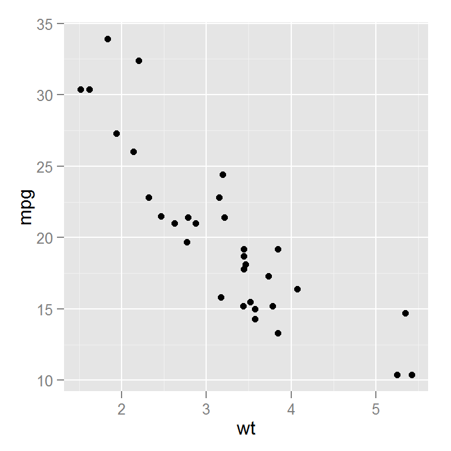

```r
g <- ggplot(mtcars,aes(x=wt,y=mpg)) + geom_point()
g
```

### Símbolos

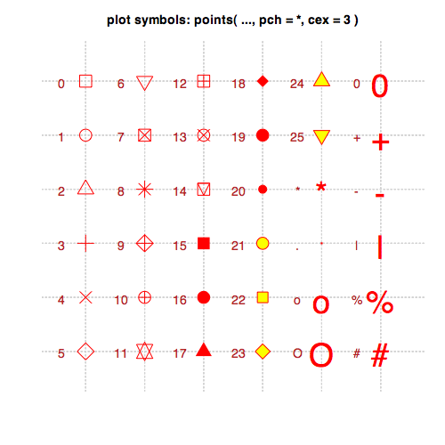

Alterando o Gráfico

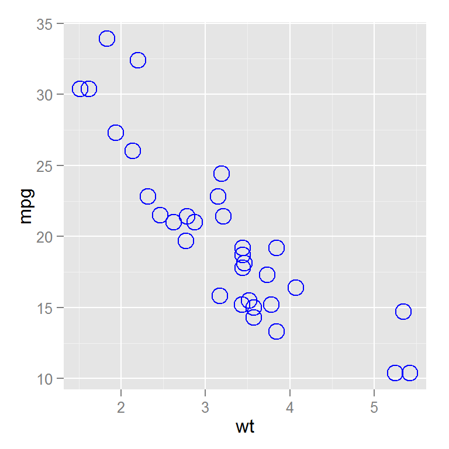

```r
g <- ggplot(mtcars,aes(x=wt,y=mpg)) + geom_point(shape=21,size=5,color="blue")
g
```

Alterando o Gráfico

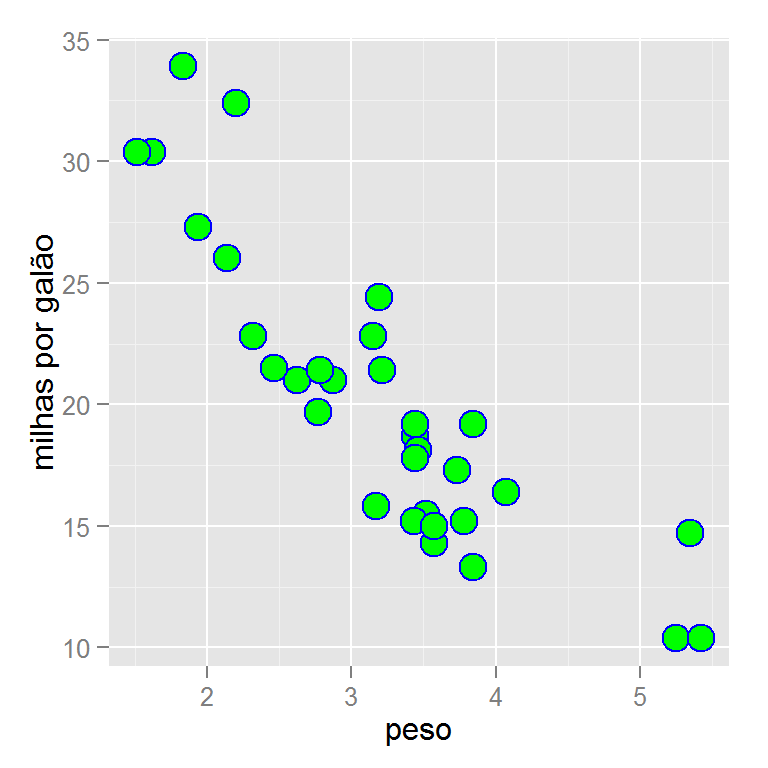

```r
g <- ggplot(mtcars,aes(x=wt,y=mpg))
g <- g + geom_point(shape=21,size=5,color="blue",fill="green")
g <- g + xlab("peso") + ylab("milhas por galão")
g
```

Fazendo mapas temáticos Cilindros por tamanho

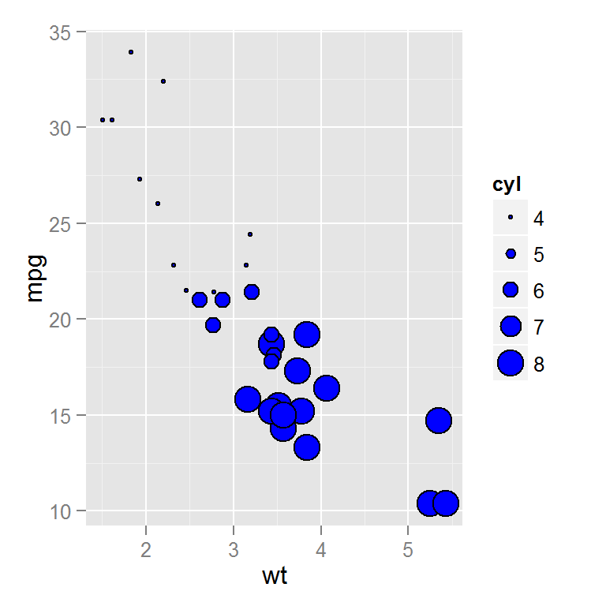

```r
g <- ggplot(mtcars,aes(x=wt, y=mpg,size=cyl))
g <- g + geom_point(fill="blue",shape=21)
g
```

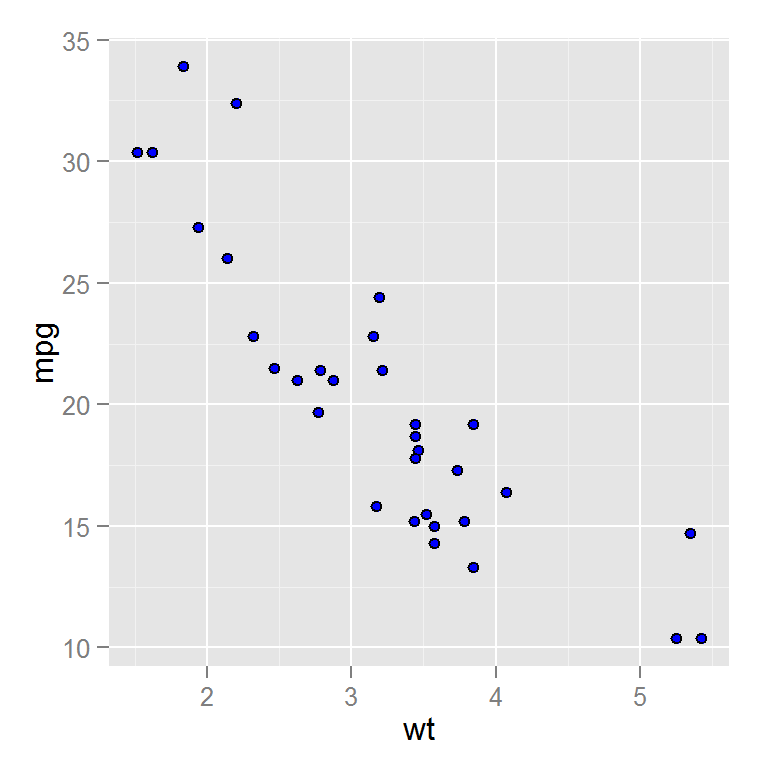

```r
g <- ggplot(mtcars,aes(x=wt, y=mpg,fill=cyl))
g <- g + geom_point(fill="blue",shape=21)
g
```

Você encontra o erro ?

Melhorando…

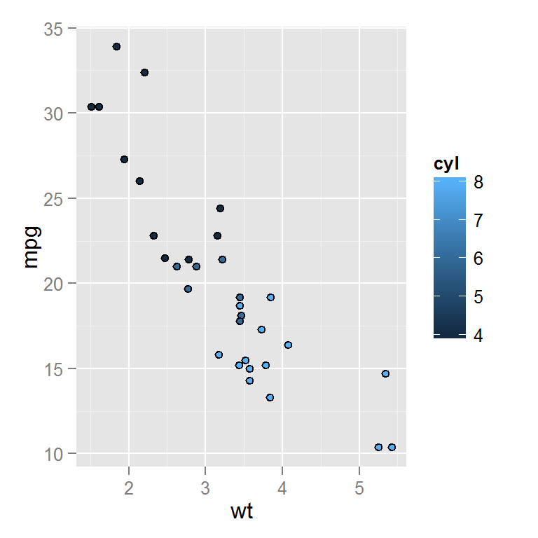

```r
g <- ggplot(mtcars,aes(x=wt, y=mpg,fill=cyl))
g <- g + geom_point(shape=21)
g
```

E agora…

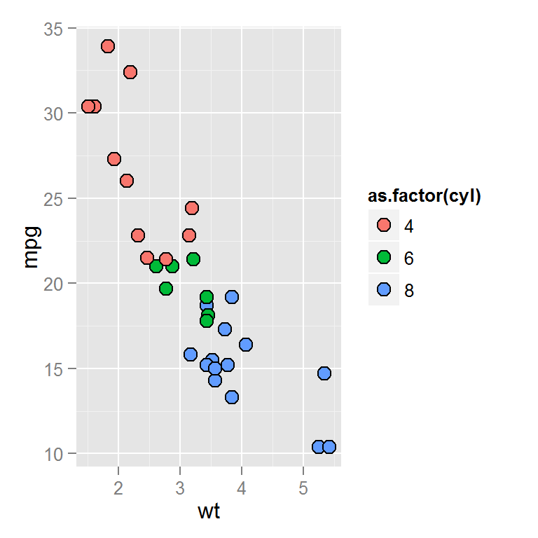

```r
g <- ggplot(mtcars,aes(x=wt, y=mpg,fill= as.factor(cyl)))
g <- g + geom_point(shape=21,size=3.5)
g
```

E agora…

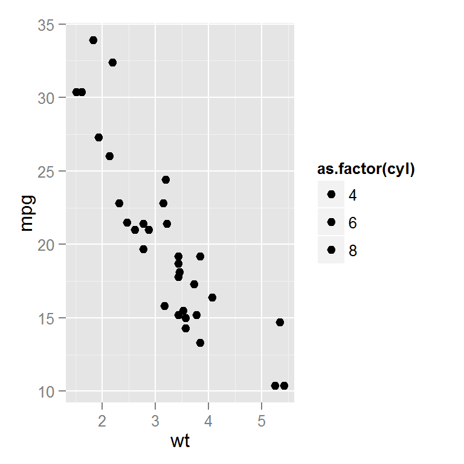

```r
g <- ggplot(mtcars,aes(x=wt, y=mpg,fill= as.factor(cyl)))
g <- g + geom_point(shape=20,size=3.5)
g
```

o que está errado ?

Gráficos Em barras

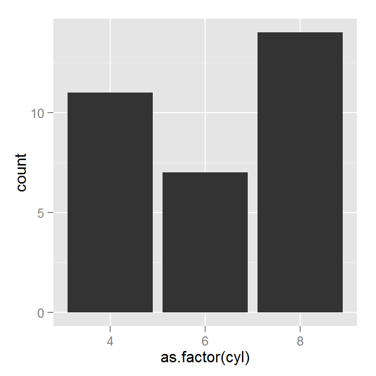

```r
g <- ggplot(mtcars,aes(x=as.factor(cyl))) + geom_bar()
g
```

Ajustando as Barras

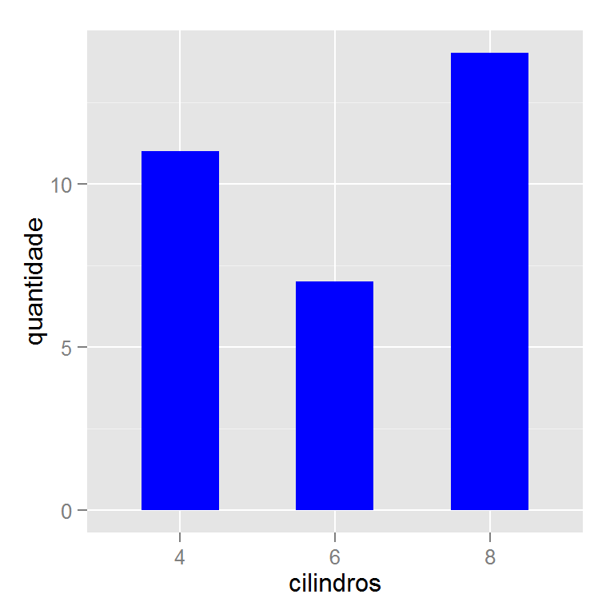

```r
g <- ggplot(mtcars,aes(x=as.factor(cyl))) + geom_bar(width=0.5,fill="blue")
g<- g + xlab("cilindros") + ylab("quantidade")
g
```

Histograma

```
## stat_bin: binwidth defaulted to range/30. Use 'binwidth = x' to adjust this.
```

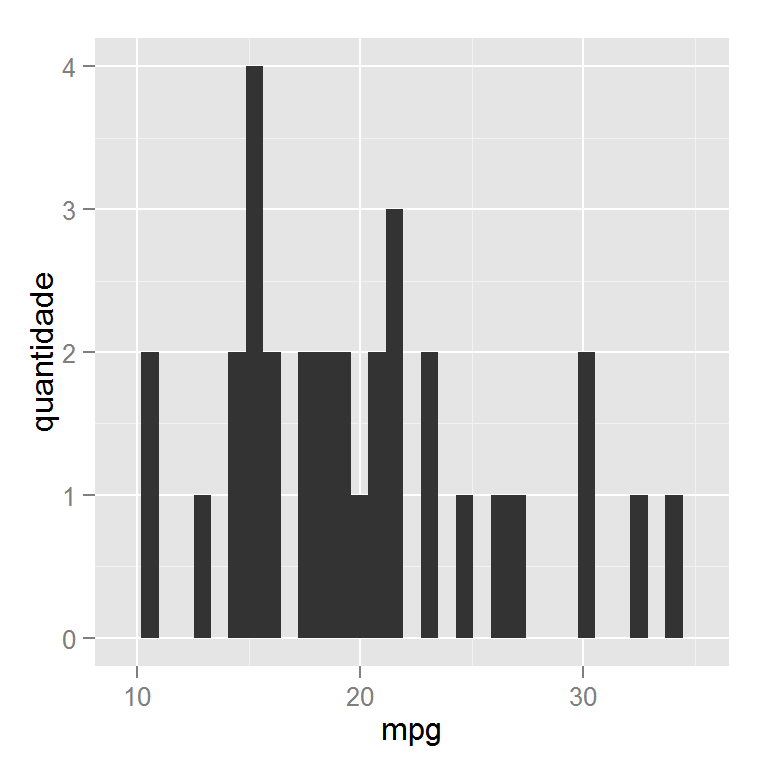

```r
g <- ggplot(mtcars,aes(x=mpg)) + geom_histogram()
g<- g + xlab("mpg") + ylab("quantidade")
g
```

Densidade de Probabilidade

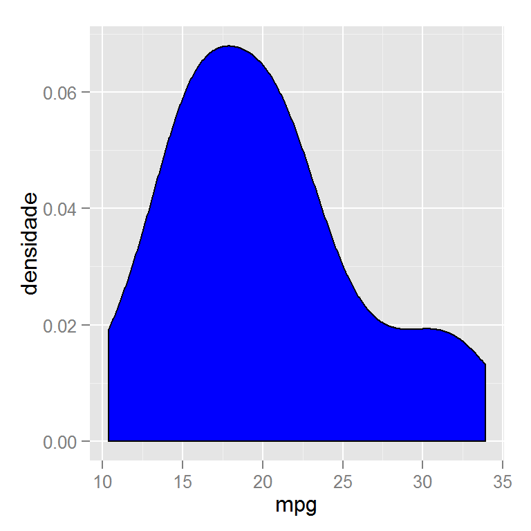

```r
g <- ggplot(mtcars,aes(x=mpg)) + geom_density(fill="blue")
g<- g + xlab("mpg") + ylab("densidade")
g
```

Box plot

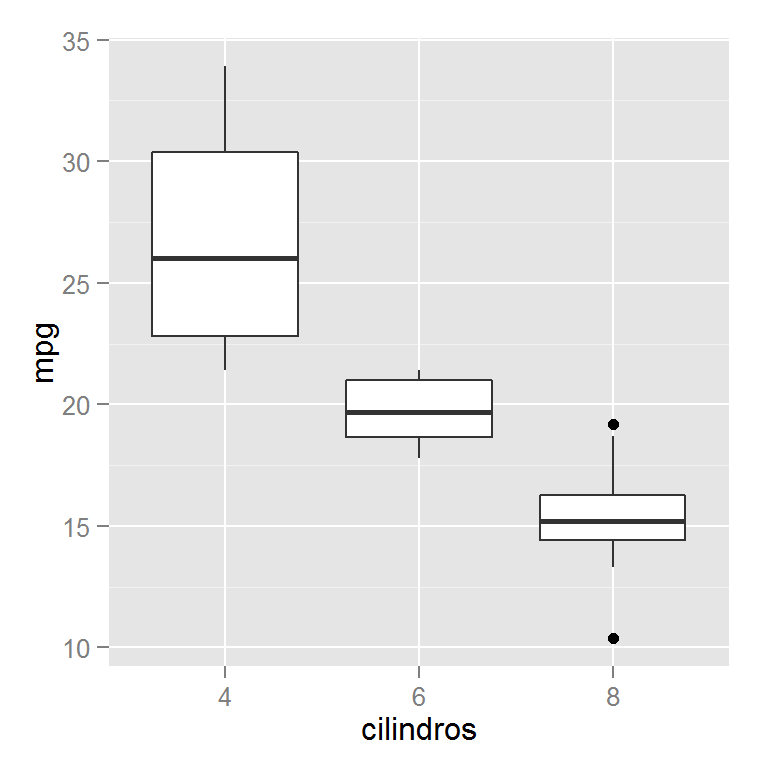

```r
g <- ggplot(mtcars,aes(y=mpg,x=factor(cyl))) + geom_boxplot()
g <- g + xlab("cilindros") + ylab("mpg")
g
```

Facets

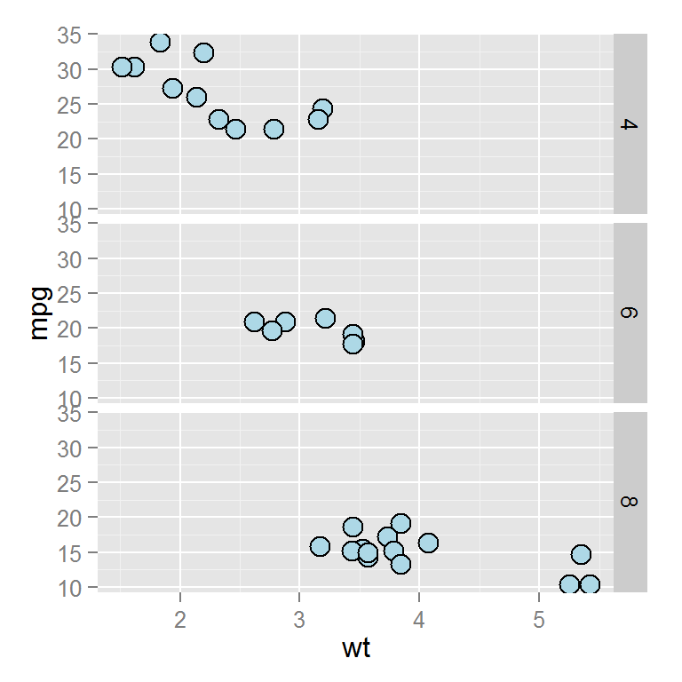

```r
g <- ggplot(mtcars,aes(x=wt,y=mpg))
g <- g + geom_point(shape=21,size=4,fill="lightblue")
g <- g + facet_grid(cyl~.)
g
```

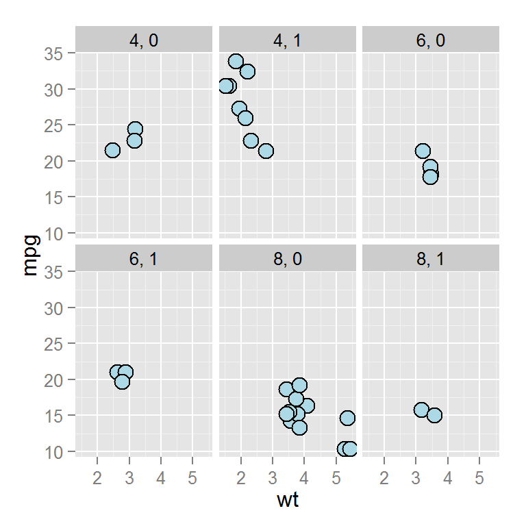

```r
g <- ggplot(mtcars,aes(x=wt,y=mpg))
g <- g + geom_point(shape=21,size=4,fill="lightblue")
g <- g + facet_wrap(cyl~am)
g
```

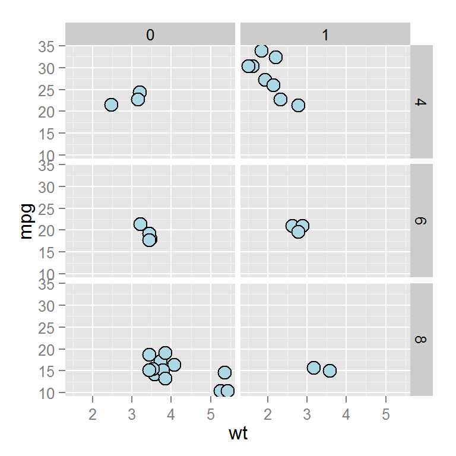

```r
g <- ggplot(mtcars,aes(x=wt,y=mpg))
g <- g + geom_point(shape=21,size=4,fill="lightblue")
g <- g + facet_grid(cyl~am)
g
```

Facet + Temático